# France ’40 - Rules Summary

# Effects Summary

|  | ZOC | ZBond | MOV | ATK | DEF | Lead DD |
| --- | --- | --- | --- | --- | --- | --- |
| Minor River |  |  | +1~2 MPs[^1] |  | (Double) |  |
| Major River |  | △ | +1~2 MPs[^2] | Half | (Double) |  |
| Disrupted |  | X | TAC only | X | Half | X |
| Full Retreat[^3] | X | X |  | X | X | X |
| GQG/Halt! |  |  | TAC only | X |  |  |
| OOS[^4] |  |  | TAC only | Half |  |  |
| Entrained | X | X | ~15 rails | X | 1 | X |

# 2. Basic Information

## 2.2. Terrain

- Marsh River is a Major River.
- Marsh around a minor River upgrades the hexside to a Major River hexside.
- Restricted (Hexes): [Wooded Rough / Marsh]
- German never benefit from Allied Fortified Hexes.

## 2.3. Counter Information

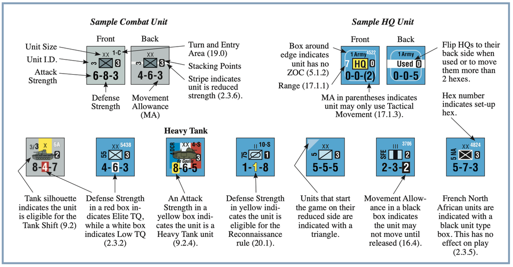

### 2.3.4. Unit Type

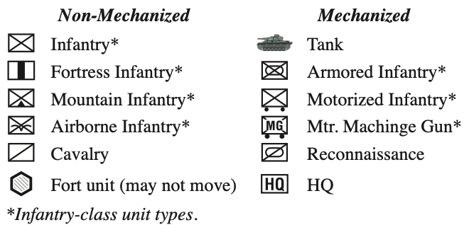

# 4. Stacking

- Can stack up to 7 Stacking Points (SPs).
- Units of the same division can never be more than 3SPs.
- Every stack is allowed to have one tank unit with 2- SPs even if exceeding the stacking limit.
- Stacking Limit can never be exceeded except during [MOV / AAC / Retreat].

# 5. ZOC

- ZOCs extend across all hexsides except All-Sea/Tidal River hexsides.
- HQs and Fort do not exert ZOC.
- **Types**: Uncontested / Contested / Negated
- **Entering**: Stop upon entering EZOC (No extra cost).
- **Leaving**: +2MPs. May move directly from EZOC to EZOC.
- **Losing**: Entry Hex / Train / Full Retreat

# 6. ZOC Bond

- **Eligibility**: Good Order & 2+ DEF STR & Exerting ZOC
  - Can form a ZOC Hexside Bond with a friendly map edge.
- **Restriction**: Cannot form ZOC Bond if
  - Through City
  - All-Sea/Tidal River hexside
  - Across two Major River hexsides[^5]

# 7. Movement

## 7.3. Extended Movement

- Increase MA by 2/3/4.
- May not move adj to Enemy.
- May begin adj from Enemy.

## 7.4. Tactical Movement

- All Units can move one or two hexes regardless their MA.
- May ATK.
- Abide by movement restrictions.

## 7.5. Movement & Terrain

- **Roads**: allows reduced movement rates
- **Rivers**: [+1MP (Non-mehch) / +2MPs (Mech)]. Must adj to cross unbridged Major unless Pontoon. May move normally after crossing.
- **Bridges**: [Road (Cancel) / Rail (-1MP)] of crossing costs

### 7.5.4. Pontoon Bridges

- Exist at Major River hexside where both sides are occupied by friendly Units; even [one is moving / during AAC / Disrupted / Full Retreat].
- A unit forming it may move after providing other units crossings.

## 7.6. Allied Rail Movement

- **Entraining**: Good Order units can entrain at [Town / City] 4+ hexes from German units (May move 2- hexes to reach).
- **Rail Movement** (Movement Ph)
  - 15- rail hexes, 3- units per turn
  - Must be [reinforcements / entrained in a previous turn].
  - Hexes traversed must be 4+ hexes from German [unit / controlled City].
  - May not end stacked with other Rail Moved Units.
- **Detraining**
  - Replace Train by Disrupted. May detrain in any rail hex.
  - **Allied Movement Ph Begin**: [Voluntarily / Find itself 4- hexes of Enemy]
  - **Anytime**: If forced to retreat

### 7.6.2. Train Effects

- May not ATK / 1 DEF STR / No ZOC
- No Terrain benefit if alone / No Tank Shift.
- HQ: Cannot [Ready / Shift].
- Detrain immediately if forced to retreat.

## 7.7. Automatic DS

- [Tank / TQ] Shifts may be used but not [Air / HQ] Shifts.
- Apply DS during Movement Ph if 10-1 Odd is made.
- **Procedure**: Place AutoDS (stop moving) → AAC anytime during Combat Ph

# 8. Combat

- Need not pre-declare all.
- There exist 8-1 and 9-1 columns identical to 7-1.
- **Procedure**: Compute STR Odds → Apply Shifts → dr
- **Maximum STR**: 20 Defense after [halving / doubling]. 40 Attack before halving.
- **Allied Cooperation**: French, British and Belgian units may stack and defend together, but may not attack together.
- **Selecting Step losses**
  - Infrantry Remnants are the last steps to be lost.
  - Within a German [Panzer / Motorized] divisions, a full strength unit must be selected over a reduced unit if they are stacked together.

[figure not shown]

# 9. Combat Modifiers

## 9.1. Halving & Doubling

- Never be havled nor doubled more than once.
- If both havled and doubled, use printed STR.
- Applies to individual unit and round up
  - Exception: 1-STR units are added up and then halved.
- **Halving**
  - ATK STR: OOS / across Major River / across Maginot Line / out of Restricted
  - DEF STR: Disrupted
- **Doubling**
  - DEF STR: All attackers [across Rivers / out of Restricted]

## 9.2. Combat Shifts

- One favorable column shift for either ATK or DEF
- **Tank**: DEF Terrain permitting, one column shift if only one side has Tanks.
  - ATK [across Rivers / out of Restricted] cannot provide Tank Shift, but deny DEF shift except Heavy Tanks.
  - French 2-1-6 tank cannot deny German Tank Shift.
- **Heavy Tank**: DEF Terrain permitting, Tank Shift regardless enemy tanks.
- **Air Support**: Max 1 per attack (except GT1 Sickle Cut)
- **HQ**: Max 1 per attack
- **Elite Combined Arms**: Elite Tank and Inf stacked together
- **Low Quality Units**: if all participating units are Low Quality

# 11. Determined Defense

- With Eligible Lead Unit to cancel Retreat portion except Full Retreats.
- **Eligible Lead Unit**: Good Order (Fort Unit if possible)
  - Not HQ nor Entrained.
- **Single Step Defender**: If eliminated after a successful DD, the attacker may advance into the Vacated (only) and stop.
  - If the DEF hex still contains units (HQ, Disrupted, ..) then the hex holds.
- **French Collapse**: if Lead Unit is French and OOS at the moment of DD.
- **DD Air Support**: German only. Max 1 per DD. Air Unit spent on Defensive Support can provide DD Air Support at no extra cost.

## 11.4. Desperate Defense

- Allowed if [Eliminated if retreat / Port & Losing it force OOS after retreat].
- Must choose either DD or Desperate Defense before any roll.
- Lead Unit may be selected for each attempt.
- The DD Air Support DRM is applied to every roll.
- **Restriction**: Cannot perform on [DS / DR4].
- **Procedure**
  1. Attempt DD as usual manner
  2. Fail of any type → “-/1”
  3. Try again until [Retreat cancelled / All DEF eliminiated]

# 12. Retreats

- Friendly Unit **negates EZOC** it occupies unless retreated current combat
- Retreating through friendly units do not disturb non-retreating units.
- May enter *contested EZOC (Not two consecutives)*.
- **Direction Guideline** (Must follow in the order of priority)
  1. No same hex twice. No zig-zag
  2. Avoid step losses
  3. X hexes away from departing hex (Lose a step for each unfulfilled)
  4. In Supply position
- **Over-stacking**
  - May end overstacked, but must resolve the owner’s next Movement Ph
  - If force to retreat again in the same Ph, elimininated.

## 12.2. Eliminated If

- Uncontested EZOC **except the first hex of the retreat**
- Two consecutive EZOCs
- Off Map / Prohibited / ZOC Bond / Major River (**even if bridge**)
- Ending in EZOC (May retreat exactly one more hex to avoid eliminiation, but it is not allowed for after two consecutive EZOCs).

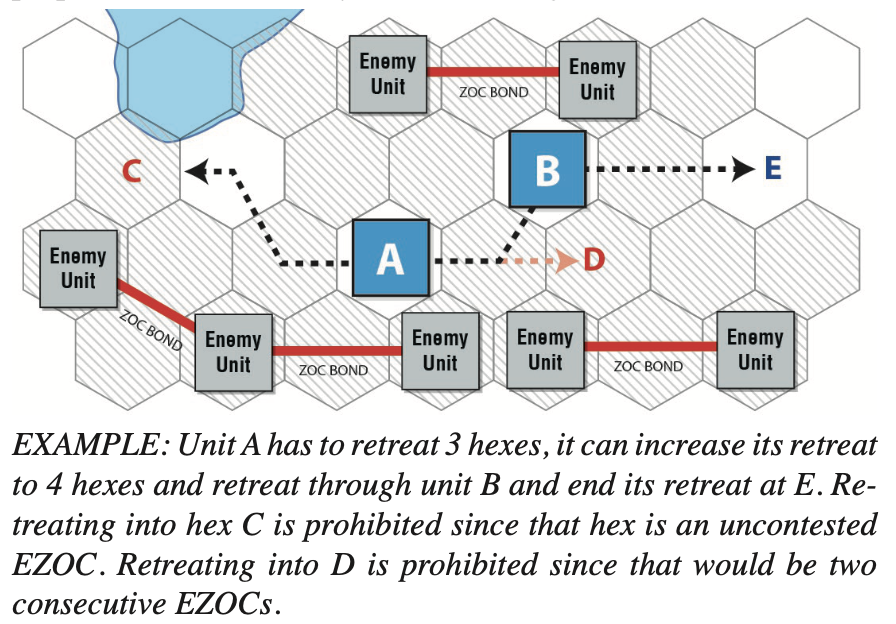

## 12.4. Stopping a Retreat

- If **ALL** the following conditions are met:
  - Retreated 1+ hexes
  - Not ending in EZOC unless a friendly non-disrupted already in the hex
  - Into [City / Fortified (Allied only)]
- Early Stoppiing does not affect [AAC result / Disruption / Full Retreat].

# 13. Disruption & Recovery

## 13.2. Distrupted

- **Not affected**: ZOC / TQ / Tank Shift
- **Limited**: TAC MOV only / DEF STR Halved
- **Restricted**: ZOC Bond / ATK / HQ Shift or Readying
- Units may [enter / pass] through friendly Disrupted units without affected.

## 13.3. Full Retreat

- **When**
  - DR4 or DS
  - Disrupted & Forced to retreat
  - Voluntarily when **Disrupted** or **GQG** (friendly Movement Ph)
- **Movement**: Full MA. May use Extended Movement.
  - Benefit: No extra cost for leaving EZOC
- **Restricted**:
  - Lose ZOCs
  - ATK / DEF / HQ Shift / HQ Ready
  - Entering EZOC unless negated
  - Cannot enter Enemy controlled City
  - Adj to Enemy
    - Must retreat 2 hexes unless in a hex with non-Disrupted
    - The Enemy may then continue [moving / advancing / retreating]

## 13.4. Recovery

- dr if EZOC, automatic otherwise.
- Full Retreat may choose not to recover.

# 14. AAC

- Units stacked together but not participating the attack can AAC together.
- Except Limited Advance, may advance in any direction.
- No need to enter the Vacated.
- Stop upon entering EZOC (even if negated) unless the Vacated.
- Stop upon crossing a Major River even if bridged
  - May only cross during the first hex of AAC.
- Cannot enter [Restricted / Prohibited].

# 15. Breakthrough Combat

- **Breakthrough Group**:
  - Forming with eligibles, applying Stacking Limit & Allied Cooperation.
  - May form in the Vacated.
  - Can drop off units from the BRK Group. The dropped end their AAC.
- Remember BRK Costs & Shifts.
- No [HQ / Air] Shifts for both sides
  - Exception: DD Air already in presence
- **Procedure**: Declare a BRK Group → AAC & BRK → Other’s AAC
- If **Fails** to [vacate / force retreat] → End the AAC.
- If **Success**, continue the AAC from [Launched / Vacated].
  - Enters the Vacated at no extra cost.
  - End in the Vacated but EZOC → [End / Try another to free itself]
- Unlike retreats from regular Combat, units that have already retreated may defend against BRK combat and are not eliminated if forced to retreat again; if overstacked, the defender choose some not to contribute.
- **No Additional Hexes**: do not earn additional AAC allowance (use initial ATK’s).

# 17. Allied HQs

- To provide HQ Shift, the HQ must 7- hexes to participating friendly unit and have the same nationality of **one of the participating** units.
- TAC MOV only if Ready, or Flip to Used for full (Mech) MA.
- Retreat 2 hexes and Disrupted if adj to Enemy
  - Full Retreat if already Disrupted.
  - Eliminated if cannot retreat.
- **Allied Initial Ph**: May Ready if [Good Order & LOS to Entry except X/N].
- **Allied Supply Ph**: No Attrition roll. Eliminated if [OOS & no LOS to non-HQ Unit].

# 18. Supply

- Check LOS during Owner’s Supply Ph → In Supply or OOS
- **Supply Source**: See Scenario rules
- Allied Units tracing LOS to three friendly controlled Cities is In Supply.

## 18.3. Line of Supply

- 5- Overland Hexes, and then, ∞ Road Hexes
  - [Wood Rough / Marsh] costs 2 Overland hexes.
- **Restrictions**: LOS cannot enter or pass
  - All-Sea/Tidal River
  - Enemy [occupied hex / controlled City / ZOC Bond]
  - EZOC (Friendly units negate EZOC they occupy for LOS); *Overland Portion may enter contested EZOC (Not two consecutives)*.

## 18.4. Effects: OOS

- **Not affected**: ZOC / DEF STR / TQ / Tank Shift
- **Limited**: TAC MOV only / ATK STR Halved / Max AAC: 2
- **Prohibited**: Replacements

## 18.5. Isolation Attrition

- dr each unit if red OOS
- **Exception**: HQ / Not adj to Enemy / Overland LOS of any length / Fort Unit stacked or adj to non-Fort Unit (Fort itself provides +2 DRM)
- May lose the last step.

# 19. Reinforcements

- **Entry Hex** is not playable. Reinforcements may not remain in those hexes or attack from them. Closed if Good Order Enemy exit the Entry.
  - May use EXT MOV to exit Entry.
- **Movement Ph**: Through Entry paying TEC cost of the first hex entered; May reinforce on ZOC but stop; delayed to the following turn if the Entry not allowed.
  - May use full MA on arrival.
- **Allied (Sickle Cut)**: Random draw as per TRT. See Reinforcement areas on the counters. Place one per hex if possible; two if not allowed. May delay to enter via adj Entry Area by Strategic Rail Movement; Place Train.
- **German**: Max one division on each Entry per turn; May 2 or 3 units constitute one division, not applicable to indep battalion (may enter with a division). Area A-# are available once some enters on the areas.

# 20. Special Rules

- **Recon Unit**: Yellow DEF STR. Ignores step loss of **[D1 / DS]** if attacked alone.
- **Rommel**: For each time [ATK / DEF / BRK / Lead DD], allowed one re-roll each.
- **Montgomery**: If **defending in Good Order**, allowed one re-roll for each [CRT / DD]; Rommel decide rerolling first if both present.
- **Disengagement (ATK)**: Good Orders may attempt Disengagement ATK once during any point of friendly Combat Ph. dr for each [Unit / Group] by Owner’s choice. Retreat 2- hexes (and Disrupted) in any direction if successful.

# 21. Sickle Cut Scenario

- **German Supply Source**: Entry [A / B / C / D]
- **Allied Supply Source**: Entry [X / N / W / S / SE / E]
- **The Dyle Line**
  - Finish construction at GT1 Allied Movement Ph End, if at least one Inf start there and stay there.
  - Removed upon [DD results / unit in the hex are eliminated or force to retreat / no friendly units present at Owner’s Supply Ph End].
- **German Mass Air Strike**: Max 3 Air Support in a single combat on GT1
- **Additional Turn (Optional)**: Upon agreement at the game start, on GT10, player with 5+VP pay 3VP to extend the game one additional turn.

## 21.2. GQG

- Grand Quartier General (GQG) slow down and prevent ATK.
- **Any Ph End**: Suffer GQG if stacked with; but can pass through without affected.
- **Units Exempt**: HQ, de Gaulle; They may freely exit and pass through GQG.
- **Return to Holding Box** if [Disrupted / sent into Full Retreat (except GT1)].

### 21.2.1. Effects: GQG

- **Not affected**: ZOC / TQ / Tank / DEF STR / Lead DD
- **Limited**: TAC MOV only
- **Prohibited**: ATK / Disengagement / Stack split / Stop voluntarily in a hex containing GQG (Allowed for a while upon inevitable situation of Retreats but resolve ASAP.)

### 21.2.4. GQG Phase

- **Procedure**: Place one per 1+ French Hex (even on Train) → Return 2- (DR)
- **How Many**: 6 (GT1) / Remainings of Holding Box (since GT2)
- **Return to Holding Box**: If GQG stack [Eliminated / Disrupted / Full Retreat]
- **Scheduled Removal**: GT3+, before placement during GQG Ph, remove one in the numerical order per turn from play (1→2→…).

## 21.3. Rundstedt’s Halt!

- **When**: Once per game, any turn GT5+, during Allied Supply Ph.
- **How**: Place 6- Halt markers on hexes containing 1+ German Mech; selected must be West further than all German non-Mech divisions. 3- hexes from German non-Mech cannot be selected.
- After placement, two dr to remove the markers matching the each dr.
- **Effect**: Same as GQG. Last for one German turn; remove after.

## 21.7. Victory Condition

- The player with the most Victory Points at the end of the game wins.

### 21.7.1. Allied VPs

- 10VP if railroad connection between [X / N] and [S / W]
  - Must be free from German Unit or EZOC
- 5VP if no railroad connection, but can trace LOS from [X / N] to [S / W]
- 1VP per multi-step German Unit Eliminated
- 1VP per multi-step German Mech with no LOS of any length

### 21.7.2. German VPs

- 10VP if Allied rail connection fails.
- 1VP for each Allied Entry closed (2VP for S/SE near Reim)
  - Must LOS at the Game End
- 1VP per German exited Entry X
  - Must trace LOS at the instant of exit

## 21.8. French Restriction

- **French Army Boundary (GT1)**
  - French north of the Sambre-Meuse line inclusive may not cross to the south of that line (1st Army/9th Army boundary line). 1st DCR is exempt.
  - French south of the Aisne-Canal des Ardennes Line may not cross to the north of that line (9th Army/2nd Army boundary line).
- **Allied Random Reinforcements Delay**
  - **GT2-5**: N and S are delayed by 1 and 2 turns, respectively.
  - **GT6-9**: S are delayed by 1 turn.

# 22. Dynamo Scenario

## 22.1 Setup

- **Game Length**: 12 turns (5/24-6/4)
- **First Player**: German
- **Map**: Dynamo map.
- **Setup**: Use the Dynamo At Start Cards
- **Halt!**: Allied places six markers before the game begins → dr 2 to remove 2-
- **Supply Source**
  - German: Any East or South Map Edge Hexes
  - Allied: Allied Port / to three Cities
- **City Control**: German controls all City hexes outside the Allied pocket.

## 22.2 Halt! Order

- Basically the same as in Sickle Cut except..
- Effective during GT 1-3. Basically same as in Sickle Cut
- **Allied Supply Ph**: Place remaining Halt! on GT 1 and 2 (dr 2 to remove 2-).
- Halt! markers are placed on Panzer divisions.
  - Two Panzer division under “May Not Move” are exempt.
  - 1st Panzer Division may not be targeted until it clears Calais of Allied Units.
  - Other units stacked with Panzer division under a Halt! are not affected.
- During GT 1-3, all German Panzer divisions must remain stacked together even those without Halt! markers.
- If Disrupted, replace Halt! by Disrupted (or Full Retreat).

## 22.3 Replacements

- **GT 1-3 (German Initial Ph)**: In Supply, Good Order, German Panzer divisions get one replacement of any kind each turn.

## 22.4 Belgian Units

- **Surrender (Any Allied Initial Ph)**: If [Brugge is German controlled / GT5], remove all Begian Units.
- **Movement Restriction**: May not enter France. Eliminated if forced to retreat. May stay in border hexes.

## 22.5 Allied Evacuations

- **GT4+ (Allied Initial Ph)**: dr (one Port) and dr (two beaches) to evacuate Units.
- If no Allied Units in Dunkirk, May evacuate Units from [Calais / Oostende].

## 22.7 Special Rules

- **Air**: German 3, Allied 2
- **Allied HQ**: Used side (cannot be flipped). 1VP per evacuation.
- **German Reinforcements**: Arrived on south map edge half hexes.
- **German Movement Restriction**
  - 2nd & 10th Panzer Divisions cannot move or attack but can defense at full.
  - 1st Panzer Division is released when Calais is cleared. It may attack Calais each turn and may advance into Calais when cleared of Enemy. Operates normally after that.
- No rail movements. No GQG.
- **German Withdrawls (GT6+)**: See TRT

## 22.8 Terrain in Dynamo

- **Polder**: *No Tank Shift*. 1MP for all Units to enter.
- **Ferry Hexsides**: Spend entire MA to across. No combat allowed.
- **Causeway Hex**: Costs 1MP for all Units. DEF double.
- **Tidal River Bridges**: +1MP to cross. No attack across.

## 22.9 0-STR Remnant

- All British Units with DEF 3+ of their last step have one additional 0-0-3 step.
- May voluntarily shed steps to become 0-0-3
- Full Retreat permanantly
- Non-mech
- 1VP per evacuation

## 22.10 Victory Conditions

- **Allied Automatic Victory**: immediately if evacuates or moves off the west or south map edge, 15+ units (10+ British).
- **End Game Victory**: Allied wins if 15+ VP, otherwise German victory
  - 1VP for each British/French unit evacuated or moved off the west or south map edge
  - 1VP for each French unit In Supply still on the map
  - 1VP for each German multi-step unit eliminated
  - -1VP for each British unit eliminated or still on the map

## Footnotes

[^1]: - Extra costs for crossing unbridged
    - May move normally after crossing.
[^2]: - Extra costs for crossing unbridged
    - May move normally after crossing.
    - Must start adj to cross unbridged (unless Pontoon).
[^3]: - Retreat immediately two hexes if adj by Enemy.
    - May leave EZOC at no extra cost.
    - May not enter EZOC unless negated.
[^4]: - AAC is limited to two hexes.
[^5]: When determining if [City / Major River] breaks, push the Hexside Bond one side; may not be pushed into a enemy unit.